# Boston Housing: A Survey of Predictive Models

Machine Learning

Regression

Model Comparison

R

Authors

Nick Polson

Vadim Sokolov

## Introduction

The Boston housing dataset contains 506 census tracts from the 1970 Boston metropolitan area. Each observation records 13 neighborhood characteristics alongside `medv`, the median home value in thousands of dollars. The goal here is straightforward: compare a range of predictive models for `medv`, from simple linear regression to neural networks, and assess each on a held-out test set.

The dataset ships with the `MASS` package. Variables include crime rate (`crim`), residential zoning (`zn`), industrial proportion (`indus`), Charles River adjacency (`chas`), nitric oxide concentration (`nox`), average rooms per dwelling (`rm`), age of units (`age`), employment distance (`dis`), highway accessibility (`rad`), tax rate (`tax`), pupil-teacher ratio (`ptratio`), Black population index (`black`), lower-status population percentage (`lstat`), and median home value (`medv`).

```r
if (!requireNamespace("kknn", quietly = TRUE)) install.packages("kknn", repos = "https://cran.rstudio.com/")
if (!requireNamespace("pls",  quietly = TRUE)) install.packages("pls",  repos = "https://cran.rstudio.com/")
library(MASS)
library(ggplot2)
library(knitr)
library(glmnet)
library(kknn)
library(tree)
library(randomForest)
library(gbm)
library(e1071)
library(nnet)
library(pls)

data(Boston)
```

## Data Exploration

### Train / Test Split

```r
set.seed(42)
n     <- nrow(Boston)
idx   <- sample(seq_len(n), size = floor(0.8 * n))
train <- Boston[idx, ]
test  <- Boston[-idx, ]
```

### Correlations with `medv`

```r
cors <- cor(Boston)[, "medv"]
cors_df <- data.frame(
  Variable    = names(cors),
  Correlation = round(cors, 3)
)
cors_df <- cors_df[order(abs(cors_df$Correlation), decreasing = TRUE), ]
kable(cors_df, row.names = FALSE, caption = "Pearson correlations with medv")
```

Pearson correlations with medv

| Variable | Correlation |
| --- | --- |
| medv | 1.000 |
| lstat | -0.738 |
| rm | 0.695 |
| ptratio | -0.508 |
| indus | -0.484 |
| tax | -0.469 |
| nox | -0.427 |
| crim | -0.388 |
| rad | -0.382 |
| age | -0.377 |
| zn | 0.360 |
| black | 0.333 |
| dis | 0.250 |
| chas | 0.175 |

### Coefficient of Variation

```r
cv_df <- data.frame(
  Variable = names(Boston),
  Mean     = round(sapply(Boston, mean), 3),
  SD       = round(sapply(Boston, sd), 3),
  CV       = round(sapply(Boston, sd) / sapply(Boston, mean), 3)
)
kable(cv_df, row.names = FALSE, caption = "Coefficient of variation for each variable")
```

Coefficient of variation for each variable

| Variable | Mean | SD | CV |
| --- | --- | --- | --- |
| crim | 3.614 | 8.602 | 2.380 |
| zn | 11.364 | 23.322 | 2.052 |
| indus | 11.137 | 6.860 | 0.616 |
| chas | 0.069 | 0.254 | 3.672 |
| nox | 0.555 | 0.116 | 0.209 |
| rm | 6.285 | 0.703 | 0.112 |
| age | 68.575 | 28.149 | 0.410 |
| dis | 3.795 | 2.106 | 0.555 |
| rad | 9.549 | 8.707 | 0.912 |
| tax | 408.237 | 168.537 | 0.413 |
| ptratio | 18.456 | 2.165 | 0.117 |
| black | 356.674 | 91.295 | 0.256 |
| lstat | 12.653 | 7.141 | 0.564 |
| medv | 22.533 | 9.197 | 0.408 |

### Scatter Matrix

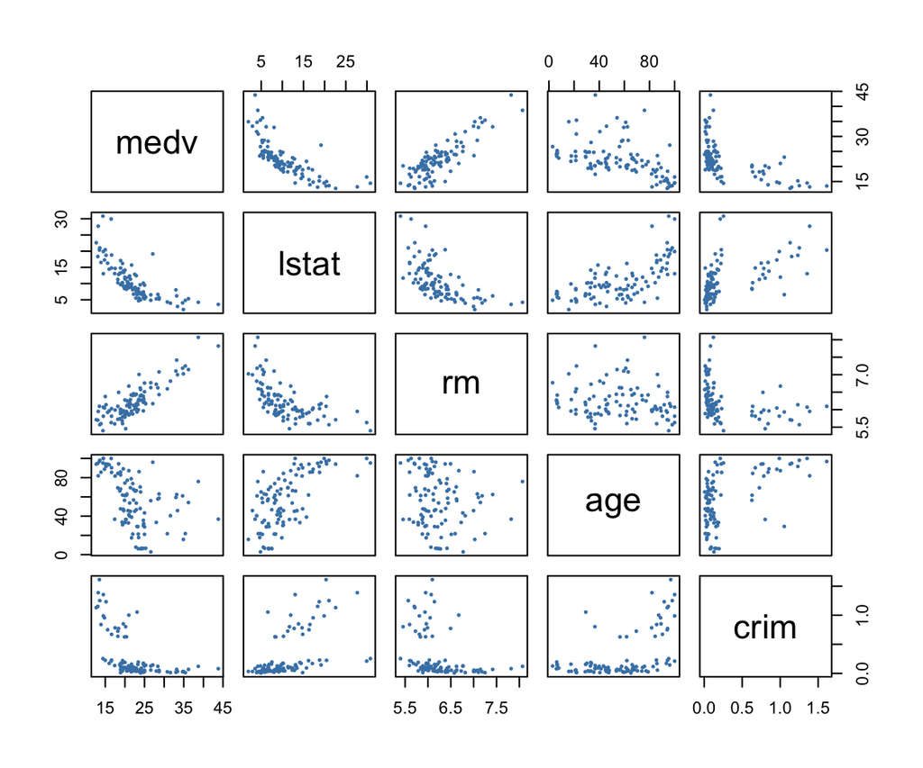

Scatter matrix: medv, lstat, rm, age, crim (first 100 obs)

```r
sub <- Boston[1:100, c("medv", "lstat", "rm", "age", "crim")]
pairs(sub, pch = 16, cex = 0.5, col = "steelblue")
```

### Evaluation Metrics

```r
metrics <- function(yhat, y) {
  rmse <- sqrt(mean((yhat - y)^2))
  mape <- mean(abs((yhat - y) / y)) * 100
  ss_res <- sum((y - yhat)^2)
  ss_tot <- sum((y - mean(y))^2)
  r2 <- 1 - ss_res / ss_tot
  c(RMSE = round(rmse, 3), MAPE = round(mape, 3), R2 = round(r2, 3))
}
```

## Linear Regression

Four specifications in increasing complexity.

```r
fit_simple <- lm(medv ~ lstat, data = train)
yhat_simple <- predict(fit_simple, test)
m_simple <- metrics(yhat_simple, test$medv)
```

```r
fit_loglog <- lm(log(medv) ~ log(lstat), data = train)
yhat_loglog <- exp(predict(fit_loglog, test))
m_loglog <- metrics(yhat_loglog, test$medv)
```

```r
fit_loglin <- lm(log(medv) ~ lstat, data = train)
yhat_loglin <- exp(predict(fit_loglin, test))
m_loglin <- metrics(yhat_loglin, test$medv)
```

```r
fit_multi <- lm(log(medv) ~ crim + chas + nox + rm + dis + ptratio + rad + black + log(lstat),
                data = train)
yhat_multi <- exp(predict(fit_multi, test))
m_multi <- metrics(yhat_multi, test$medv)
```

### Diagnostics for the Multiple Model

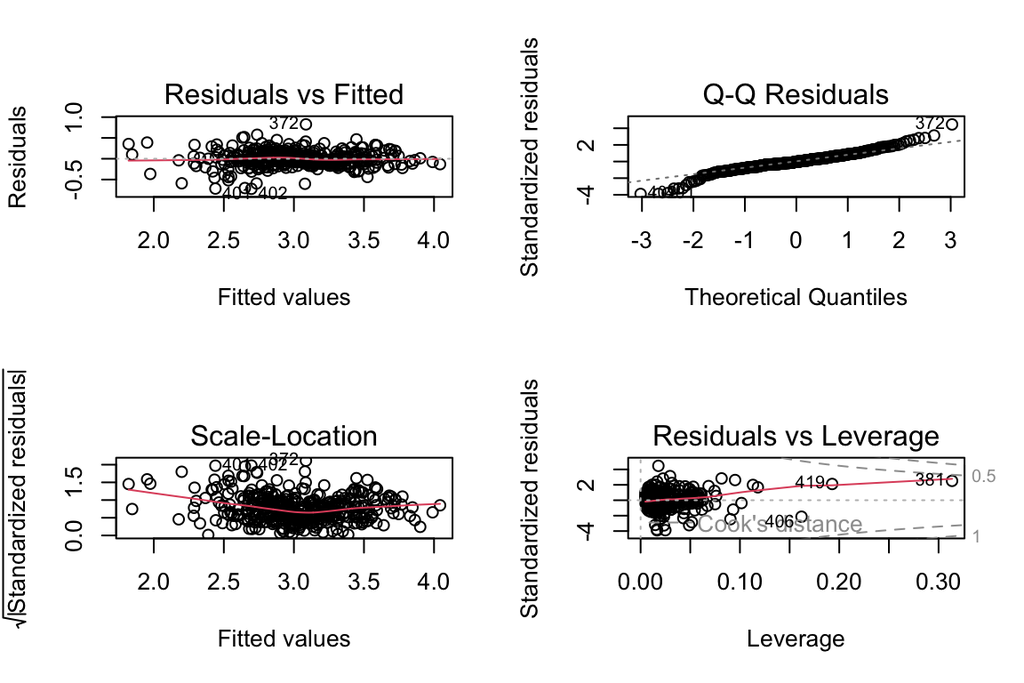

Residual diagnostics for the multiple log-linear model

```r
par(mfrow = c(2, 2))
plot(fit_multi)
```

```r
par(mfrow = c(1, 1))
```

### Linear Model Comparison

```r
lm_table <- rbind(
  "Simple (medv ~ lstat)"       = m_simple,
  "Log-log"                     = m_loglog,
  "Log-linear"                  = m_loglin,
  "Multiple log-linear"         = m_multi
)
kable(as.data.frame(lm_table), caption = "Linear model test-set performance")
```

Linear model test-set performance

|  | RMSE | MAPE | R2 |
| --- | --- | --- | --- |
| Simple (medv ~ lstat) | 6.784 | 19.739 | 0.552 |
| Log-log | 5.543 | 17.223 | 0.701 |
| Log-linear | 6.464 | 17.316 | 0.593 |
| Multiple log-linear | 4.328 | 13.653 | 0.818 |

## Ridge and Lasso

```r
X_train <- model.matrix(medv ~ ., train)[, -1]
y_train <- train$medv
X_test  <- model.matrix(medv ~ ., test)[, -1]
y_test  <- test$medv

lambdas <- 10^seq(2.5, -2, length.out = 100)
```

### Ridge

```r
fit_ridge <- glmnet(X_train, y_train, alpha = 0, lambda = lambdas)

coef_ridge <- as.matrix(coef(fit_ridge))[-1, ]
df_ridge <- as.data.frame(t(coef_ridge))
df_ridge$log_lambda <- log(lambdas)
df_long_ridge <- reshape(df_ridge,
  varying   = colnames(df_ridge)[colnames(df_ridge) != "log_lambda"],
  v.names   = "coef",
  timevar   = "variable",
  times     = colnames(df_ridge)[colnames(df_ridge) != "log_lambda"],
  direction = "long"
)
```

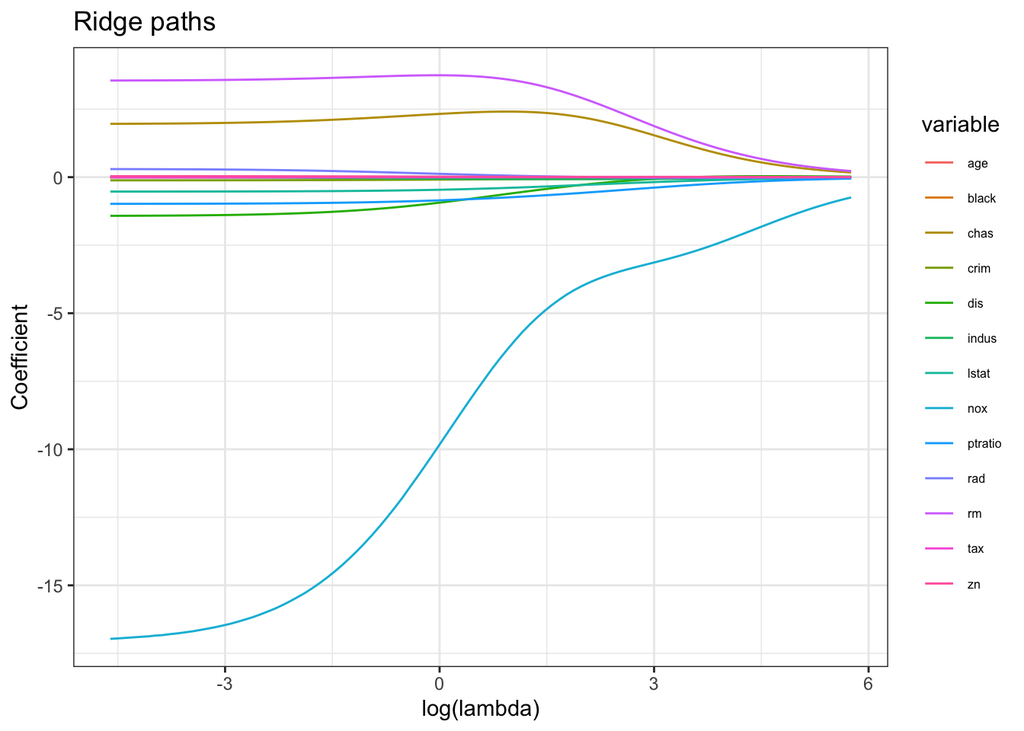

Ridge coefficient paths

```r
ggplot(df_long_ridge, aes(x = log_lambda, y = coef, color = variable)) +
  geom_line() +
  labs(x = "log(lambda)", y = "Coefficient", title = "Ridge paths") +
  theme_bw() +
  theme(legend.position = "right", legend.text = element_text(size = 6))
```

```r
rmse_ridge <- apply(predict(fit_ridge, X_test), 2,
                    function(yh) sqrt(mean((yh - y_test)^2)))
best_ridge  <- lambdas[which.min(rmse_ridge)]
yhat_ridge  <- predict(fit_ridge, X_test, s = best_ridge)
m_ridge <- metrics(yhat_ridge, y_test)
```

### Lasso

```r
fit_lasso <- glmnet(X_train, y_train, alpha = 1, lambda = lambdas)

coef_lasso <- as.matrix(coef(fit_lasso))[-1, ]
df_lasso <- as.data.frame(t(coef_lasso))
df_lasso$log_lambda <- log(lambdas)
df_long_lasso <- reshape(df_lasso,
  varying   = colnames(df_lasso)[colnames(df_lasso) != "log_lambda"],
  v.names   = "coef",
  timevar   = "variable",
  times     = colnames(df_lasso)[colnames(df_lasso) != "log_lambda"],
  direction = "long"
)
```

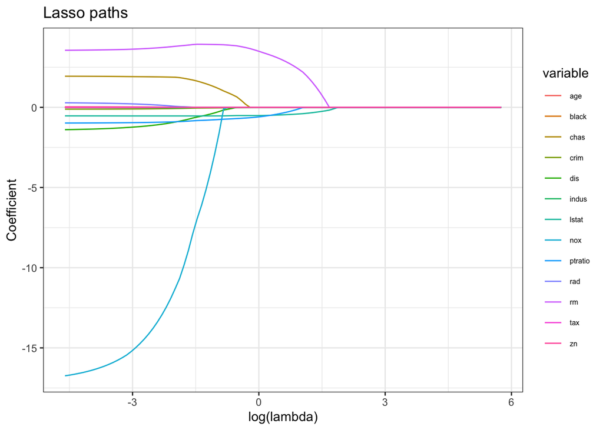

Lasso coefficient paths

```r
ggplot(df_long_lasso, aes(x = log_lambda, y = coef, color = variable)) +
  geom_line() +
  labs(x = "log(lambda)", y = "Coefficient", title = "Lasso paths") +
  theme_bw() +
  theme(legend.position = "right", legend.text = element_text(size = 6))
```

```r
rmse_lasso <- apply(predict(fit_lasso, X_test), 2,
                    function(yh) sqrt(mean((yh - y_test)^2)))
best_lasso  <- lambdas[which.min(rmse_lasso)]
yhat_lasso  <- predict(fit_lasso, X_test, s = best_lasso)
m_lasso <- metrics(yhat_lasso, y_test)
```

## KNN

```r
ks <- c(2, 10, 20, 50, 100, 300)
knn_results <- lapply(ks, function(k) {
  fit <- kknn(medv ~ ., train = train, test = test, k = k)
  list(k = k, yhat = fit$fitted.values, m = metrics(fit$fitted.values, test$medv))
})
```

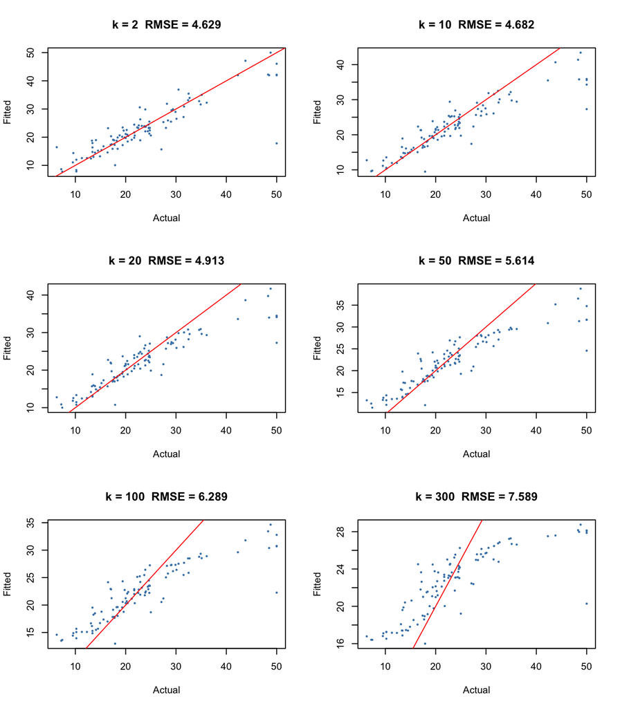

KNN: fitted vs actual for each k

```r
par(mfrow = c(3, 2))
for (res in knn_results) {
  plot(test$medv, res$yhat, pch = 16, cex = 0.5, col = "steelblue",
       xlab = "Actual", ylab = "Fitted",
       main = paste0("k = ", res$k, "  RMSE = ", res$m["RMSE"]))
  abline(0, 1, col = "red")
}
```

```r
par(mfrow = c(1, 1))
```

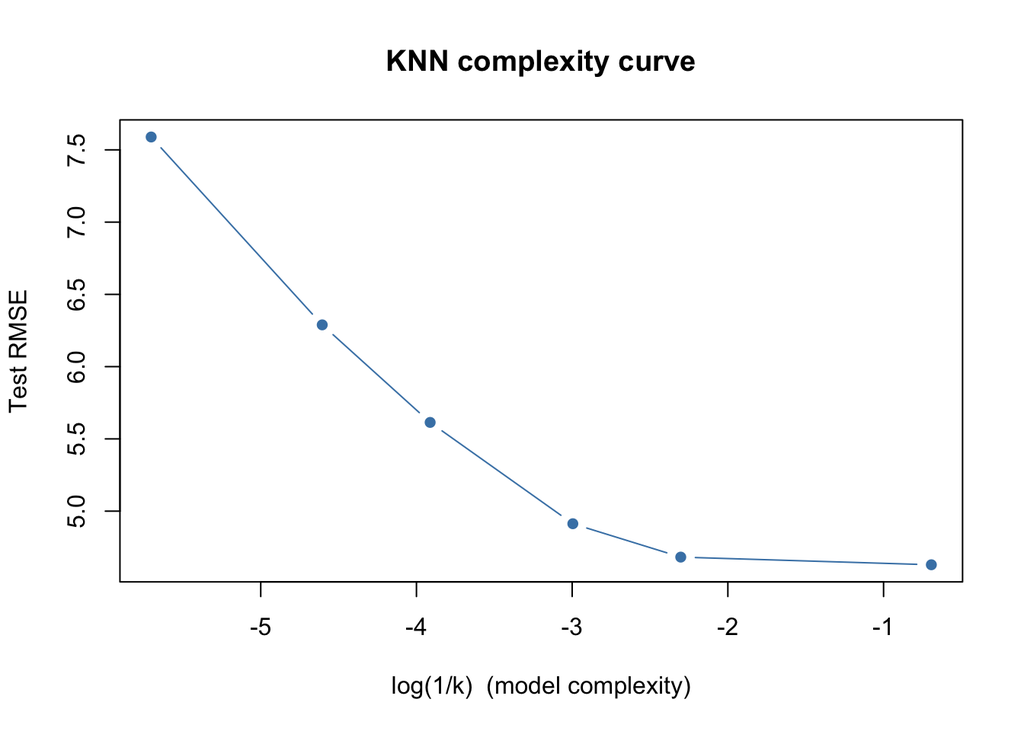

KNN test RMSE vs log(1/k)

```r
knn_rmse <- sapply(knn_results, function(r) r$m["RMSE"])
knn_k    <- sapply(knn_results, function(r) r$k)
plot(log(1 / knn_k), knn_rmse, type = "b", pch = 16, col = "steelblue",
     xlab = "log(1/k)  (model complexity)", ylab = "Test RMSE",
     main = "KNN complexity curve")
```

```r
best_k   <- knn_results[[which.min(knn_rmse)]]$k
fit_knn  <- kknn(medv ~ ., train = train, test = test, k = best_k)
m_knn <- metrics(fit_knn$fitted.values, test$medv)
```

## Tree Models

### Single Tree: `medv ~ lstat`

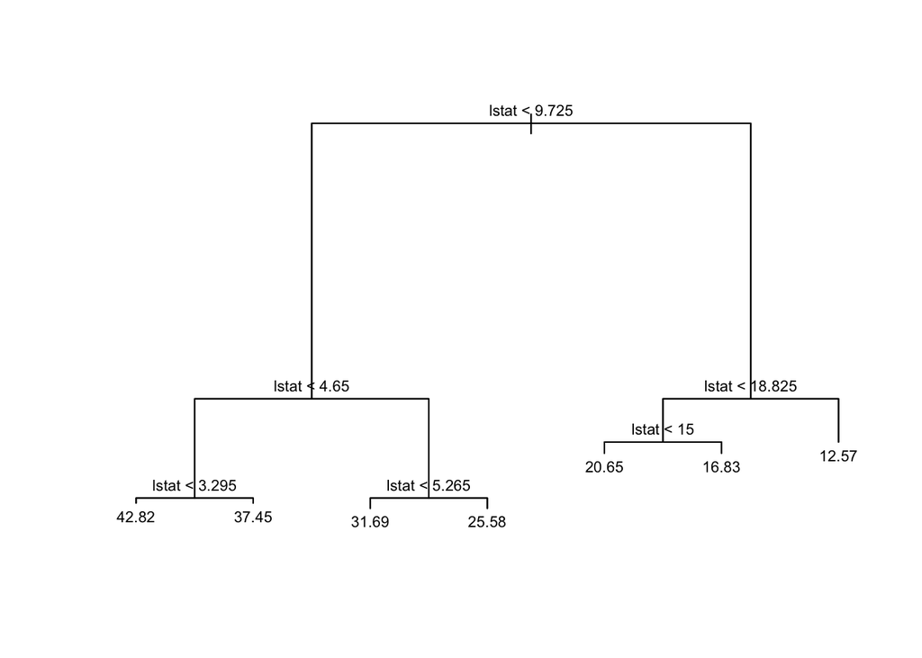

Pruned tree (7 leaves): medv vs lstat

```r
big_tree1 <- tree(medv ~ lstat, data = train, mindev = 0.0001)
pruned1   <- prune.tree(big_tree1, best = 7)
plot(pruned1)
text(pruned1, cex = 0.7)
```

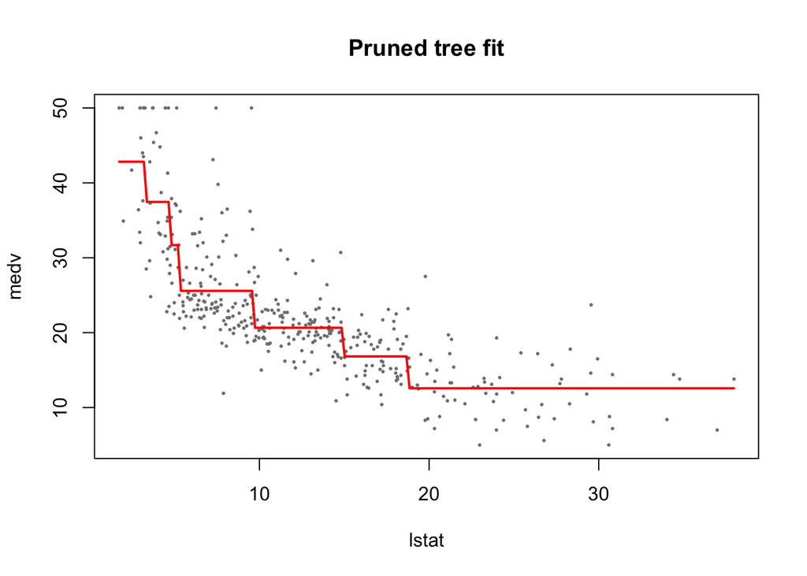

Step-function fit: pruned tree on lstat

```r
lstat_seq <- seq(min(train$lstat), max(train$lstat), length.out = 200)
pred_seq  <- predict(pruned1, data.frame(lstat = lstat_seq))
plot(train$lstat, train$medv, pch = 16, cex = 0.4, col = "gray50",
     xlab = "lstat", ylab = "medv", main = "Pruned tree fit")
lines(lstat_seq, pred_seq, col = "red", lwd = 2)
```

### 2D Tree: `medv ~ lstat + dis`

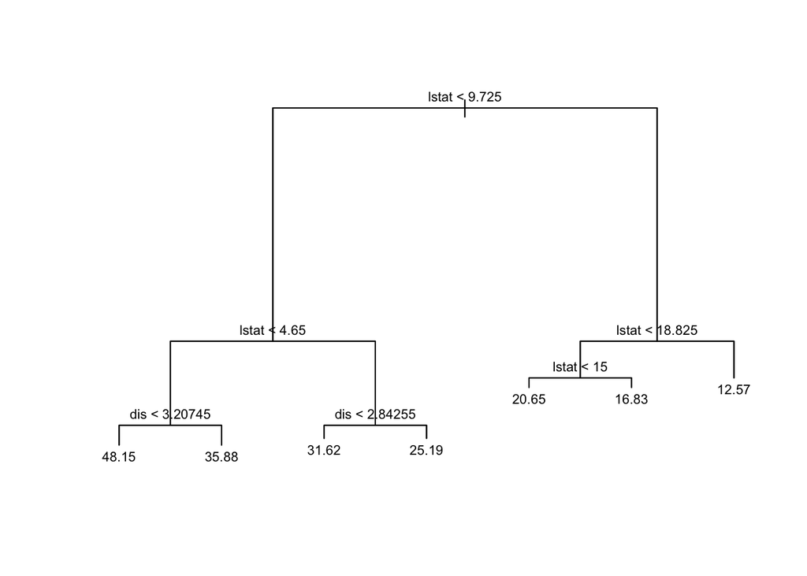

Pruned 2D tree

```r
big_tree2 <- tree(medv ~ lstat + dis, data = train, mindev = 0.0001)
pruned2   <- prune.tree(big_tree2, best = 7)
plot(pruned2)
text(pruned2, cex = 0.7)
```

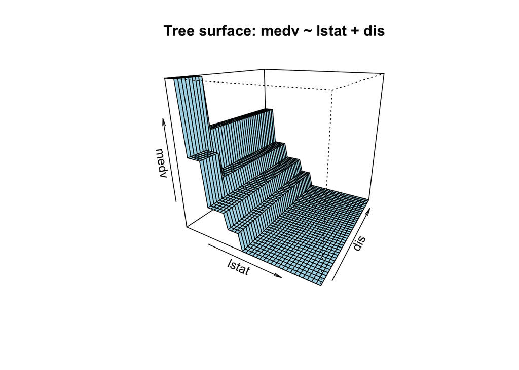

Perspective plot: predicted medv over lstat x dis

```r
lstat_g <- seq(min(train$lstat), max(train$lstat), length.out = 40)
dis_g   <- seq(min(train$dis),   max(train$dis),   length.out = 40)
grid    <- expand.grid(lstat = lstat_g, dis = dis_g)
grid$z  <- predict(pruned2, grid)
z_mat   <- matrix(grid$z, 40, 40)
persp(lstat_g, dis_g, z_mat, theta = 30, phi = 20,
      xlab = "lstat", ylab = "dis", zlab = "medv",
      main = "Tree surface: medv ~ lstat + dis", col = "lightblue")
```

### Full Tree with Cross-Validation

```r
big_tree_full <- tree(medv ~ ., data = train, mindev = 0.0001)
cv_tree  <- cv.tree(big_tree_full)
best_sz  <- cv_tree$size[which.min(cv_tree$dev)]
pruned_full <- prune.tree(big_tree_full, best = best_sz)
yhat_tree   <- predict(pruned_full, test)
m_tree <- metrics(yhat_tree, test$medv)
```

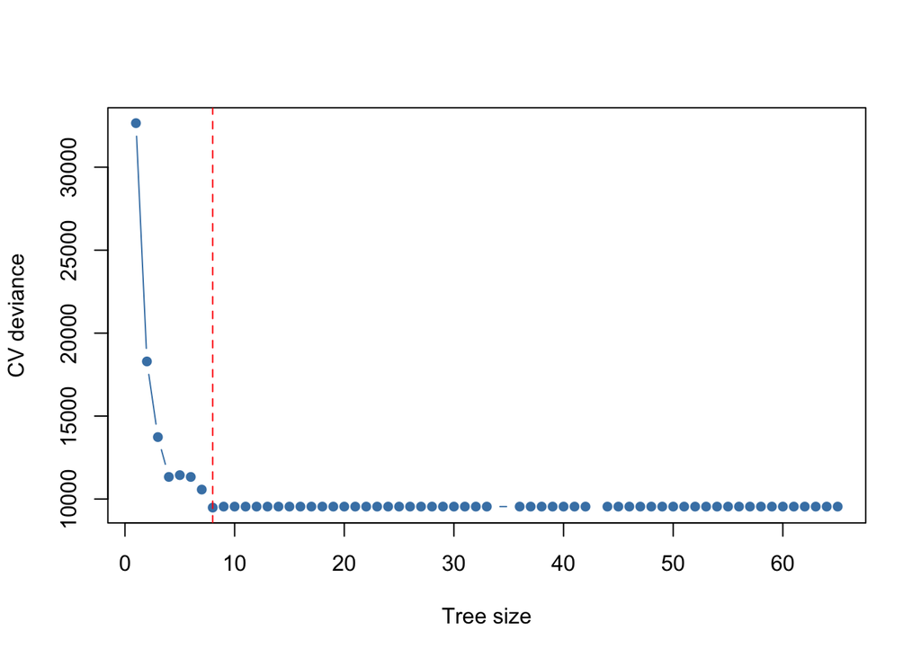

CV deviance vs tree size

```r
plot(cv_tree$size, cv_tree$dev, type = "b", pch = 16, col = "steelblue",
     xlab = "Tree size", ylab = "CV deviance")
abline(v = best_sz, col = "red", lty = 2)
```

## Random Forest

```r
set.seed(42)
fit_rf13 <- randomForest(medv ~ ., data = train, mtry = 13)
fit_rf6  <- randomForest(medv ~ ., data = train, mtry = 6)

yhat_rf13 <- predict(fit_rf13, test)
yhat_rf6  <- predict(fit_rf6,  test)
m_rf13 <- metrics(yhat_rf13, test$medv)
m_rf6  <- metrics(yhat_rf6,  test$medv)
```

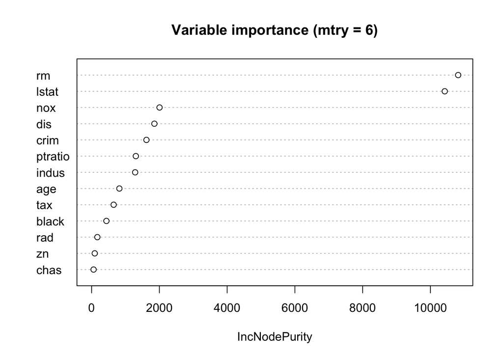

Variable importance: random forest (mtry = 6)

```r
varImpPlot(fit_rf6, main = "Variable importance (mtry = 6)")
```

## Boosting

```r
set.seed(42)
fit_gbm <- gbm(medv ~ ., data = train,
               n.trees           = 5000,
               interaction.depth = 4,
               shrinkage         = 0.01,
               verbose           = FALSE)
```

```
Distribution not specified, assuming gaussian ...
```

```r
fit_gbm2 <- gbm(medv ~ ., data = train,
                n.trees           = 5000,
                interaction.depth = 4,
                shrinkage         = 0.2,
                verbose           = FALSE)
```

```
Distribution not specified, assuming gaussian ...
```

```r
best_iter  <- gbm.perf(fit_gbm,  method = "OOB", plot.it = FALSE)
best_iter2 <- gbm.perf(fit_gbm2, method = "OOB", plot.it = FALSE)

yhat_gbm  <- predict(fit_gbm,  test, n.trees = best_iter)
yhat_gbm2 <- predict(fit_gbm2, test, n.trees = best_iter2)
m_gbm  <- metrics(yhat_gbm,  test$medv)
m_gbm2 <- metrics(yhat_gbm2, test$medv)
```

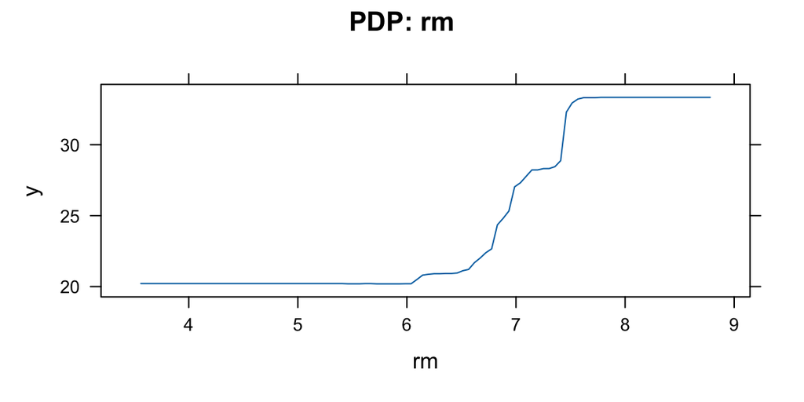

Partial dependence: rm (left) and lstat (right)

```r
par(mfrow = c(1, 2))
plot(fit_gbm, i.var = "rm",    n.trees = best_iter, main = "PDP: rm")
```

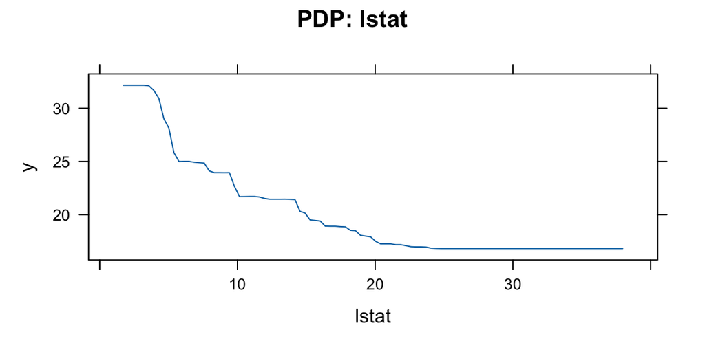

Partial dependence: rm (left) and lstat (right)

```r
plot(fit_gbm, i.var = "lstat", n.trees = best_iter, main = "PDP: lstat")
```

```r
par(mfrow = c(1, 1))
```

## SVM

Binary target: `medv > 25`.

```r
dat_svm <- Boston
dat_svm$high <- factor(ifelse(dat_svm$medv > 25, "high", "low"))
train_svm <- dat_svm[idx, ]
test_svm  <- dat_svm[-idx, ]

train_svm <- train_svm[, names(train_svm) != "medv"]
test_svm  <- test_svm[,  names(test_svm)  != "medv"]

fit_svm <- svm(high ~ ., data = train_svm, kernel = "radial",
               cost = 1, scale = TRUE)
pred_svm <- predict(fit_svm, test_svm)
acc_svm  <- mean(pred_svm == test_svm$high)
```

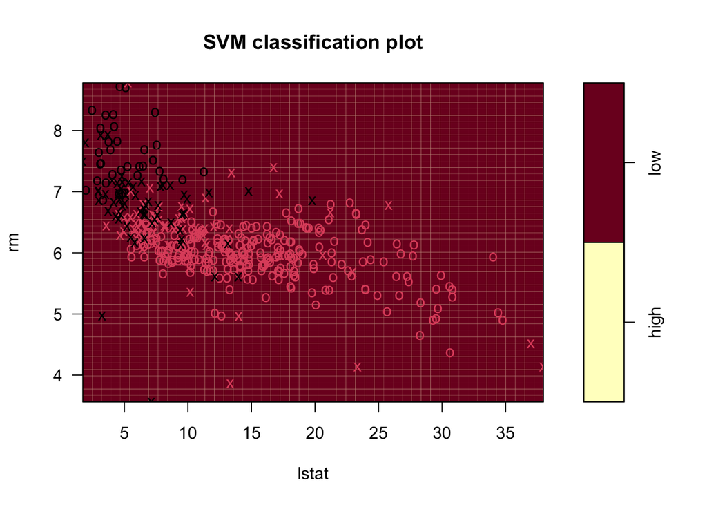

SVM decision boundary: rm vs lstat

```r
plot(fit_svm, train_svm, rm ~ lstat)
```

## Logistic Regression

### Binary

```r
train_bin <- train
train_bin$high <- ifelse(train$medv > 25, 1, 0)
test_bin  <- test
test_bin$high  <- ifelse(test$medv  > 25, 1, 0)

fit_glm <- glm(high ~ . - medv, data = train_bin, family = binomial)
pred_glm_prob <- predict(fit_glm, test_bin, type = "response")
pred_glm_cls  <- ifelse(pred_glm_prob > 0.5, 1, 0)
acc_glm <- mean(pred_glm_cls == test_bin$high)
```

### Multinomial

Three classes: low ($\leq 17$), medium ($17 < \text{medv} \leq 25$), high ($> 25$).

```r
train_multi <- train
train_multi$cls <- cut(train$medv, breaks = c(-Inf, 17, 25, Inf),
                       labels = c("low", "medium", "high"))

test_multi <- test
test_multi$cls <- cut(test$medv, breaks = c(-Inf, 17, 25, Inf),
                      labels = c("low", "medium", "high"))

fit_multi_cls <- multinom(cls ~ . - medv, data = train_multi, trace = FALSE)
pred_multi    <- predict(fit_multi_cls, test_multi)
acc_multi     <- mean(pred_multi == test_multi$cls)
```

## Neural Network

```r
library(keras)

X_nn  <- scale(X_train)
X_ts  <- scale(X_test,
               center = attr(X_nn, "scaled:center"),
               scale  = attr(X_nn, "scaled:scale"))
y_nn  <- y_train
y_ts  <- y_test

model <- keras_model_sequential() |>
  layer_dense(64, activation = "relu", input_shape = ncol(X_nn)) |>
  layer_dense(64, activation = "relu") |>
  layer_dense(32, activation = "relu") |>
  layer_dense(1)

model |> compile(
  loss      = "mse",
  optimizer = optimizer_rmsprop()
)

history <- model |> fit(
  X_nn, y_nn,
  epochs          = 20,
  batch_size      = 32,
  validation_split = 0.1,
  verbose         = 0
)

yhat_nn <- as.vector(predict(model, X_ts))
m_nn <- metrics(yhat_nn, y_ts)
```

The network uses two hidden layers of 64 units each, followed by a 32-unit layer, all with ReLU activations. Training uses MSE loss and RMSprop for 20 epochs with a 10% validation split. The architecture is intentionally small to avoid overfitting on 400 training observations.

## PLS and PLS + Random Forest

```r
fit_pls <- plsr(medv ~ ., data = train, ncomp = 10, validation = "CV")
ncomp_opt <- which.min(RMSEP(fit_pls)$val[1, 1, -1])
yhat_pls  <- predict(fit_pls, test, ncomp = ncomp_opt)
m_pls <- metrics(as.vector(yhat_pls), test$medv)
```

```r
pls_scores_train <- scores(fit_pls)[, 1:ncomp_opt]
pls_scores_test  <- predict(fit_pls, test, type = "scores")[, 1:ncomp_opt]

df_pls_train <- data.frame(pls_scores_train, medv = train$medv)
df_pls_test  <- data.frame(pls_scores_test)
names(df_pls_test) <- names(df_pls_train)[-ncol(df_pls_train)]

set.seed(42)
fit_pls_rf <- randomForest(medv ~ ., data = df_pls_train)
yhat_pls_rf <- predict(fit_pls_rf, df_pls_test)
m_pls_rf <- metrics(yhat_pls_rf, test$medv)
```

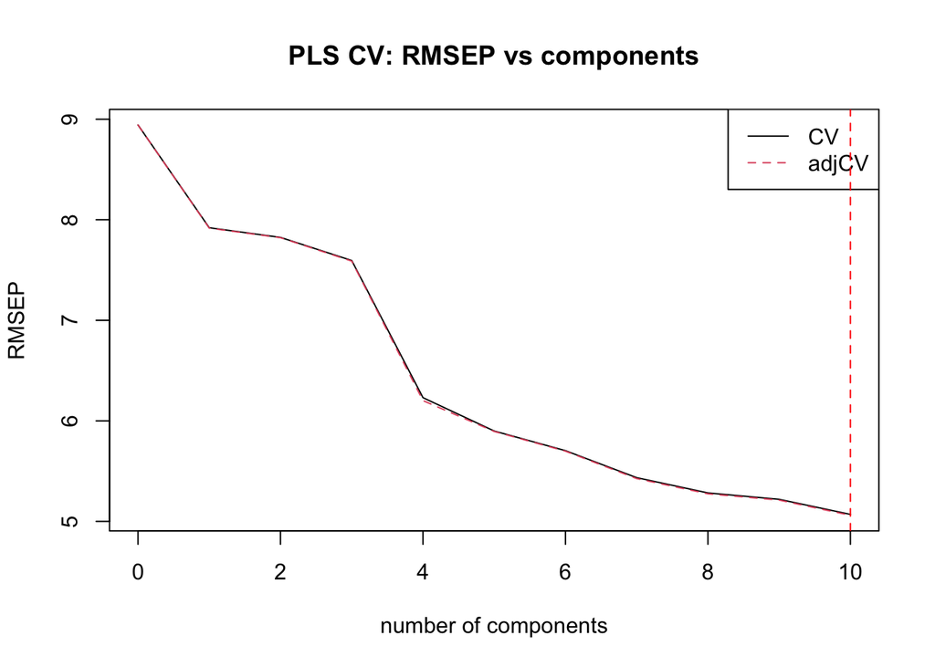

PLS cross-validation RMSEP

```r
plot(RMSEP(fit_pls), legendpos = "topright", main = "PLS CV: RMSEP vs components")
abline(v = ncomp_opt, col = "red", lty = 2)
```

## Summary

```r
results <- rbind(
  "Linear: simple"              = m_simple,
  "Linear: log-log"             = m_loglog,
  "Linear: log-linear"          = m_loglin,
  "Linear: multiple log-linear" = m_multi,
  "Ridge (best lambda)"         = m_ridge,
  "Lasso (best lambda)"         = m_lasso,
  "KNN"                         = m_knn,
  "Tree (pruned, CV)"           = m_tree,
  "Random Forest (mtry=13)"     = m_rf13,
  "Random Forest (mtry=6)"      = m_rf6,
  "GBM (shrinkage=0.01)"        = m_gbm,
  "GBM (shrinkage=0.2)"         = m_gbm2,
  "PLS"                         = m_pls,
  "PLS + Random Forest"         = m_pls_rf
)
rownames(results)[7] <- paste0("KNN (k=", best_k, ")")

kable(as.data.frame(results),
      caption = "Test-set performance: all models",
      digits  = 3)
```

Test-set performance: all models

|  | RMSE | MAPE | R2 |
| --- | --- | --- | --- |
| Linear: simple | 6.784 | 19.739 | 0.552 |
| Linear: log-log | 5.543 | 17.223 | 0.701 |
| Linear: log-linear | 6.464 | 17.316 | 0.593 |
| Linear: multiple log-linear | 4.328 | 13.653 | 0.818 |
| Ridge (best lambda) | 4.790 | 16.042 | 0.777 |
| Lasso (best lambda) | 4.797 | 15.996 | 0.776 |
| KNN (k=2) | 4.629 | 13.078 | 0.791 |
| Tree (pruned, CV) | 4.362 | 17.840 | 0.815 |
| Random Forest (mtry=13) | 2.848 | 10.568 | 0.921 |
| Random Forest (mtry=6) | 3.247 | 10.741 | 0.897 |
| GBM (shrinkage=0.01) | 3.752 | 12.105 | 0.863 |
| GBM (shrinkage=0.2) | 3.244 | 12.334 | 0.898 |
| PLS | 5.145 | 15.958 | 0.742 |
| PLS + Random Forest | 4.879 | 14.660 | 0.768 |